# Scripts to analyse a replication of Bott and Chemla 2016.Scripts to analyse a replication of Bott and Chemla 2016

# # Refining the data

Our dataset contains a lot of information, and before proceeding there are two operations which we’ll perform. First, we’ll exclude filler trails, which will allow for more straightforward analysis code. Second, we’ll exclude trains in which the respondents did not choose the ‘correct’ primes, in line with Bott and Chemla.

Tthe following table will be useful to keep in mind as it shows that raw counts of trails relative to prime and response type.

```r
table(p$responseTypeText, p$primeTypeText)
```

```
##
##          "ALL" "NUM4" "NUM6" "SOME"
##   "ALL"     12      0      0      0
##   "NUM4"     0     32      0     32
##   "NUM6"     0      0      8      0
##   "SOME"     0     32      0     32
```

So, let’s filter out the filler trials from the CSV First, we can check how many fillers we have.

```r
table(p$trial_type)
```

```
##
##   "filler" "response"
##         20        128
```

Second, we filter the CSV using the subset operation.

```r
rp = subset(p, trial_type=='"response"')
```

Finally, we can check we’ve done the right thing.

```r
table(rp$trial_type)
```

```
##
##   "filler" "response"
##          0        128
```

Next, we can now filter the CSV so that we only have entries for correct prime responses.

First, we see how many correct/incorrect prime responses there were.

```r
table(rp$correctPChoices)
```

```
##
## false  true
##    28   100
```

```r
prop.table(table(rp$correctPChoices))
```

```
##
##   false    true
## 0.21875 0.78125
```

Second, filter using the fact that we had the foresight to log whether the respondant chose the correct primes.

```r
rp = subset(rp, correctPChoices=='true')
```

And again, we can check we’ve done the right thing

```r
table(rp$correctPChoices)
```

```
##
## false  true
##     0   100
```

We can now have a peak at how the strength of primes influences the responses of participants.

```r
table(rp$primeStrengthText, rp$responseChoiceText)
```

```
##
##            "better" "weak"
##   "strong"       31     15
##   "weak"         35     19
```

We can now look at the raw counts of prime and reponse types again, if we like.

```r
table(p$responseTypeText, p$primeTypeText)
```

```
##
##          "ALL" "NUM4" "NUM6" "SOME"
##   "ALL"     12      0      0      0
##   "NUM4"     0     32      0     32
##   "NUM6"     0      0      8      0
##   "SOME"     0     32      0     32
```

# # Further Subsets of data

There are two important subsets of the data we’ll be interested in analysing. The first is within category priming, and the second is between category priming. In the following two subsections we create two distinct datasets from the original data. We won’t actually use these in creating models, but they can be useful to look at the details.

# # # Within category priming dataset

For the within category priming dataset we need to ensure that the prime category and the response category are the same. So, we use the ‘subset’ function to exclude the results for which the prime category differs from the response category, using the fact that we’ve logged the relation between primes and response.

```r
table(rp$withBet)
```

```
## < table of extent 0 >
```

```r
wrp = subset(rp, WithBet=='"within"')
```

We can look at the refined dataset, if we wish, by uncommeting the following code.

```r
# summary(wrp)
```

We can also check that we’ve got the right restrictions, we’re aiming for the diagonal (ignoring fillers categories)

```r
table(wrp$responseTypeText, wrp$primeTypeText)
```

```
##
##          "ALL" "NUM4" "NUM6" "SOME"
##   "ALL"      0      0      0      0
##   "NUM4"     0     26      0      0
##   "NUM6"     0      0      0      0
##   "SOME"     0      0      0     26
```

# # # Between category priming dataset

As in the case of within category priming, we use the fact that we’ve logged the relation between primes and responses to exclude cases in which the prime and response category differs.

```r
brp = subset(rp, WithBet=='"between"')
```

As before, we can check that we’ve got the right restrictions.

```r
table(brp$responseTypeText, brp$primeTypeText)
```

```
##
##          "ALL" "NUM4" "NUM6" "SOME"
##   "ALL"      0      0      0      0
##   "NUM4"     0      0      0     23
##   "NUM6"     0      0      0      0
##   "SOME"     0     25      0      0
```

We’re now ready to create a model!

# # The broad dataset

First, let’s look at the dataset where the only operation we’ve performed is removing fillers, and trails for which the participant did not choose the correct responses for the primes they saw. Follow Bott and Chemla, we’ll be using a logit mixed-effect model, so ‘gmler’ does the trick.

```r
rp.model = glmer(responseChoice ~ primeStrength*WithBet + (1 + primeStrength*WithBet | workerid), data=rp, family="binomial")
```

```r
summary(rp.model)
```

```
## Generalized linear mixed model fit by maximum likelihood (Laplace
##   Approximation) [glmerMod]
##  Family: binomial  ( logit )
## Formula: responseChoice ~ primeStrength * WithBet + (1 + primeStrength *
##     WithBet | workerid)
##    Data: rp
##
##      AIC      BIC   logLik deviance df.resid
##     63.6    100.1    -17.8     35.6       86
##
## Scaled residuals:
##     Min      1Q  Median      3Q     Max
## -3.5685  0.0000  0.0000  0.2358  0.5195
##
## Random effects:
##  Groups   Name                          Variance Std.Dev. Corr
##  workerid (Intercept)                     1853    43.05
##           primeStrength                   1601    40.01   -1.00
##           WithBet"within"                 1685    41.05   -1.00  1.00
##           primeStrength:WithBet"within" 385902   621.21    0.61 -0.64
##
##
##
##
##  -0.63
## Number of obs: 100, groups:  workerid, 4
##
## Fixed effects:
##                               Estimate Std. Error z value Pr(>|z|)
## (Intercept)                      15.93      46.30   0.344  0.73088
## primeStrength                   -14.20      46.27  -0.307  0.75891
## WithBet"within"                 -15.14      46.26  -0.327  0.74339
## primeStrength:WithBet"within"    69.97      25.29   2.767  0.00566 **
## ---
## Signif. codes:  0 '***' 0.001 '**' 0.01 '*' 0.05 '.' 0.1 ' ' 1
##
## Correlation of Fixed Effects:
##             (Intr) prmStr WthB""
## primStrngth -0.998
## WthBt"wthn" -0.999  0.999
## prmStr:WB"" -0.018  0.020  0.019
## convergence code: 0
## unable to evaluate scaled gradient
## Model failed to converge: degenerate  Hessian with 2 negative eigenvalues
```

# # Within detail

Now let’s take a look at the case of within category priming. The parameters we use follow those of Bott and Chemla

```r
rp.modelWithin = glmer(responseChoice ~ primeStrength * WithCat +  (1 + primeStrength * WithCat | workerid), data=rp, family = binomial(link = "logit"))
summary(rp.modelWithin)
```

```
## Generalized linear mixed model fit by maximum likelihood (Laplace
##   Approximation) [glmerMod]
##  Family: binomial  ( logit )
## Formula: responseChoice ~ primeStrength * WithCat + (1 + primeStrength *
##     WithCat | workerid)
##    Data: rp
##
##      AIC      BIC   logLik deviance df.resid
##     63.1     99.6    -17.6     35.1       86
##
## Scaled residuals:
##     Min      1Q  Median      3Q     Max
## -3.5680 -0.0001  0.0001  0.2450  0.5209
##
## Random effects:
##  Groups   Name                        Variance Std.Dev. Corr
##  workerid (Intercept)                    8.861  2.977
##           primeStrength                430.753 20.755    1.00
##           WithCat"SOME"                442.691 21.040    1.00  1.00
##           primeStrength:WithCat"SOME" 1615.056 40.188   -1.00 -1.00 -1.00
## Number of obs: 100, groups:  workerid, 4
##
## Fixed effects:
##                             Estimate Std. Error z value Pr(>|z|)
## (Intercept)                    0.690      1.724   0.400    0.689
## primeStrength                 11.577    190.150   0.061    0.951
## WithCat"SOME"                 11.884    208.894   0.057    0.955
## primeStrength:WithCat"SOME"  -22.546    225.847  -0.100    0.920
##
## Correlation of Fixed Effects:
##             (Intr) prmStr WC"SOM
## primStrngth  0.006
## WthCt"SOME"  0.015 -0.362
## pS:WC"SOME" -0.016 -0.507 -0.620
## convergence code: 0
## unable to evaluate scaled gradient
## Model failed to converge: degenerate  Hessian with 1 negative eigenvalues
```

# # Between detail

```r
rp.modelBetween = glmer(responseChoice ~ primeStrength * BetCat  +  (1 + primeStrength * BetCat | workerid), data=rp, family = binomial(link = "logit"))
summary(rp.modelBetween)
```

```
## Generalized linear mixed model fit by maximum likelihood (Laplace
##   Approximation) [glmerMod]
##  Family: binomial  ( logit )
## Formula: responseChoice ~ primeStrength * BetCat + (1 + primeStrength *
##     BetCat | workerid)
##    Data: rp
##
##      AIC      BIC   logLik deviance df.resid
##    115.2    229.8    -13.6     27.2       56
##
## Scaled residuals:
##      Min       1Q   Median       3Q      Max
## -2.23972 -0.00004  0.00003  0.00099  0.85154
##
## Random effects:
##  Groups   Name                           Variance Std.Dev. Corr
##  workerid (Intercept)                      3.231   1.797
##           primeStrength                  195.113  13.968    1.00
##           BetCat"NUM4SOME"               354.414  18.826    0.98  0.99
##           BetCat"SOMENUM4"               249.692  15.802    0.98  0.97
##           BetCat"SOMESOME"               593.904  24.370    0.99  0.99
##           primeStrength:BetCat"NUM4SOME"  81.337   9.019    0.39  0.40
##           primeStrength:BetCat"SOMENUM4" 792.491  28.151   -1.00 -0.99
##           primeStrength:BetCat"SOMESOME" 400.749  20.019   -0.10 -0.11
##
##
##
##
##   0.93
##   0.99  0.95
##   0.41  0.33  0.28
##  -0.96 -0.99 -0.98 -0.36
##  -0.12  0.02 -0.16  0.12  0.04
## Number of obs: 100, groups:  workerid, 4
##
## Fixed effects:
##                                  Estimate Std. Error z value Pr(>|z|)
## (Intercept)                     4.673e-02  1.116e+00   0.042    0.967
## primeStrength                   7.230e+00  7.874e+01   0.092    0.927
## BetCat"NUM4SOME"                1.068e+01  3.963e+02   0.027    0.978
## BetCat"SOMENUM4"                8.650e+00  1.277e+02   0.068    0.946
## BetCat"SOMESOME"                1.192e+01  1.410e+03   0.008    0.993
## primeStrength:BetCat"NUM4SOME" -7.292e+00  1.895e+03  -0.004    0.997
## primeStrength:BetCat"SOMENUM4" -1.480e+01  1.504e+02  -0.098    0.922
## primeStrength:BetCat"SOMESOME"  6.628e+00  2.164e+04   0.000    1.000
##
## Correlation of Fixed Effects:
##             (Intr) prmStr BC"NUM BC"SOMEN BC"SOMES pS:BC"N pS:BC"SOMEN
## primStrngth  0.075
## BC"NUM4SOME  0.019  0.003
## BC"SOMENUM4  0.051  0.007  0.002
## BC"SOMESOME  0.008  0.001  0.000  0.001
## pS:BC"NUM4S  0.001 -0.041 -0.209  0.000    0.000
## pS:BC"SOMEN -0.081 -0.529 -0.003 -0.852   -0.001    0.021
## pS:BC"SOMES  0.000 -0.004  0.000  0.000   -0.065    0.000   0.002
## convergence code: 0
## unable to evaluate scaled gradient
## Model failed to converge: degenerate  Hessian with 11 negative eigenvalues
## failure to converge in 10000 evaluations
```

# # Set the theme

```r
theme_set(theme_bw())
```

```r
summary(p)
```

[output not shown]

[output cut: 113 more lines]

```
##
##  assignmentrejecttime deadline feedback reject   Answer.catch_trials
##  "":148               "":148   "":148   "":148   "[]":148
##
##
##
##
##
##     Answer.condition          Answer.time_in_minutes
##  "undefined":148     "13.099916666666667":37
##                      "2.8508833333333334":37
##                      "5.4764"            :37
##                      "6.9995"            :37
##
##
```

# Visualisation

First, let’s construct percentages of ‘better’ responses for each prime and response category pairing. Recall, responseChoice returns 0 for a weak selection, and 1 for a selection of ‘better’, which Bott and Chemla take to indicate the desire for a pragmatically enriched ‘strong’ card.

```r
p.perc <- ddply(p,.(BetCat, primeStrengthText),summarise,prop = sum(as.numeric(as.character(responseChoice)))/length(responseChoice))
p.perc
```

```
##        BetCat primeStrengthText      prop
## 1    "ALLALL"          "strong" 0.5000000
## 2    "ALLALL"            "weak" 0.2500000
## 3  "NUM4NUM4"          "strong" 0.7500000
## 4  "NUM4NUM4"            "weak" 0.5625000
## 5  "NUM4SOME"          "strong" 0.6875000
## 6  "NUM4SOME"            "weak" 0.7500000
## 7  "NUM6NUM6"          "strong" 0.3333333
## 8  "NUM6NUM6"            "weak" 0.4000000
## 9  "SOMENUM4"          "strong" 0.6875000
## 10 "SOMENUM4"            "weak" 0.7500000
## 11 "SOMESOME"          "strong" 0.6875000
## 12 "SOMESOME"            "weak" 0.7500000
```

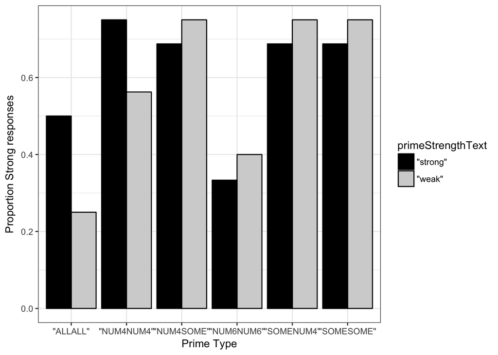

```r
ggplot(p.perc,aes(x=factor(BetCat),y=prop, fill=primeStrengthText, label=paste(round(prop*100), "%"))) +
  geom_bar(stat="identity", colour="black", position=position_dodge()) +
  ylab("Proportion Strong responses") +
  xlab("Prime Type") +
  scale_fill_manual(values=c("black", "lightgray"))
```

# # Individual plots

An alernative approach seems to be to generate plots for each category indepndently. Here’s some example code to do this.

```r
psswp = subset(p, trial_type=='response' & BetCat=="SOMESOME")
summary(psswp)
```

[output not shown]

[output cut: 106 more lines]

```
##
##  assignmentrejecttime deadline feedback reject Answer.catch_trials
##  "":0                 "":0     "":0     "":0   "[]":0
##
##
##
##
##
##     Answer.condition          Answer.time_in_minutes
##  "undefined":0       "13.099916666666667":0
##                      "2.8508833333333334":0
##                      "5.4764"            :0
##                      "6.9995"            :0
##
##
```

```r
psswp.perc <- ddply(psswp,.(primeStrengthText),summarise,prop = sum(as.integer(as.character(responseChoice)))/length(responseChoice))

# ggplot(psswp.perc,aes(x=factor(primeStrengthText),y=psswp.perc,label=paste(round(psswp.perc*100), "%")),fill=primeStrength) +
#   geom_bar(colour="black", stat="identity", position=position_dodge()) +
#   ylab("Proportion Strong responses") +
#   xlab("Prime Type") +
#   scale_fill_manual(values=c("black", "lightgray"))
```

```r
cc = subset(p, trial_type=='response' & (BetCat=="ADHSOME" | BetCat=="SOMEADH"))
summary(cc)
```

[output not shown]

[output cut: 106 more lines]

```
##
##  assignmentrejecttime deadline feedback reject Answer.catch_trials
##  "":0                 "":0     "":0     "":0   "[]":0
##
##
##
##
##
##     Answer.condition          Answer.time_in_minutes
##  "undefined":0       "13.099916666666667":0
##                      "2.8508833333333334":0
##                      "5.4764"            :0
##                      "6.9995"            :0
##
##
```

```r
cc.perc <- ddply(cc,.(primeStrengthText),summarise,prop = sum(responseChoice)/length(responseChoice))
cc.perc
```

```
##  [1] workerid               pOChoice               pTChoice
##  [4] primeTypeText          rt                     responseType
##  [7] WithBet                correctPChoices        responseChoice
## [10] WithCatN               responseChoiceText     responseTypeText
## [13] correctPOChoice        WithCat                primeType
## [16] BetCat                 BetCatN                trial_type
## [19] goodPOChoice           WithBetN               correctPTChoice
## [22] primeStrength          primeStrengthText      goodPTChoice
## [25] language               enjoyment              gender
## [28] age                    problems               comments
## [31] asses                  fairprice              education
## [34] OS                     screenH                screenW
## [37] Browser                hitid                  hittypeid
## [40] title                  description            keywords
## [43] reward                 creationtime           assignments
## [46] numavailable           numpending             numcomplete
## [49] hitstatus              reviewstatus           annotation
## [52] assignmentduration     autoapprovaldelay      hitlifetime
## [55] viewhit                assignmentid           workerid.1
## [58] assignmentstatus       autoapprovaltime       assignmentaccepttime
## [61] assignmentsubmittime   assignmentapprovaltime assignmentrejecttime
## [64] deadline               feedback               reject
## [67] Answer.catch_trials    Answer.condition       Answer.time_in_minutes
## <0 rows> (or 0-length row.names)
```

Here I can’t figure out how to make the bars different colours.

```r
# ggplot(cc.perc,aes(x=factor(primeStrengthText),y=prop,label=paste(round(prop*100), "%"))) +
#   geom_bar(colour="black", stat="identity", position=position_dodge()) +
#   ylab("Proportion Strong responses") +
#   xlab("Prime Type") +
#   scale_fill_manual(values=c("black", "lightgrey"))
```